# Lyapunov Exponent and Out-of-Time-Ordered Correlator's Growth Rate in a Chaotic System

Efim B. Rozenbaum, Sriram Ganeshan, and Victor Galitski

It was proposed recently that the out-of-time-ordered four-point correlator (OTOC) may serve as a useful characteristic of quantum-chaotic behavior, because, in the semiclassical limit $\hbar\rightarrow0$, its rate of exponential growth resembles the classical Lyapunov exponent. Here, we calculate the four-point correlator $C(t)$ for the classical and quantum kicked rotor -- a textbook driven chaotic system -- and compare its growth rate at initial times with the standard definition of the classical Lyapunov exponent. Using both quantum and classical arguments, we show that the OTOC's growth rate and the Lyapunov exponent are, in general, distinct quantities, corresponding to the logarithm of the phase-space averaged divergence rate of classical trajectories and to the phase-space average of the logarithm, respectively. The difference appears to be more pronounced in the regime of low kicking strength $K$, where no classical chaos exists globally. In this case, the Lyapunov exponent quickly decreases as $K\rightarrow0$, while the OTOC's growth rate may decrease much slower, showing a higher sensitivity to small chaotic islands in the phase space. We also show that the quantum correlator as a function of time exhibits a clear singularity at the Ehrenfest time $t_E$: transitioning from a time-independent value of $t^{-1}\ln C(t)$ at $t<t_E$ to its monotonic decrease with time at $t>t_E$. We note that the underlying physics here is the same as in the theory of weak (dynamical) localization [Aleiner and Larkin, Phys. Rev. B 54, 14423 (1996); Tian, Kamenev, and Larkin, Phys. Rev. Lett. 93, 124101 (2004)] and is due to a delay in the onset of quantum interference effects, which occur sharply at a time of the order of the Ehrenfest time.

DOI: http://dx.doi.org/10.1103/PhysRevLett.118.086801

## Introduction

One of the central goals in the study of quantum chaos is to establish a correspondence principle between classical and quantum dynamics of classically chaotic systems [1–7]. Several previous works [7–11] have attempted to recover fingerprints of classical chaos in quantum dynamics. In particular, Aleiner and Larkin [12] showed the existence of a semiclassical "quantum chaotic" regime attributed to the delay in the onset of quantum effects (due to weak localization) revealing the key measure of classical chaos—the Lyapunov exponent (LE). Recently, the subject of quantum chaos has been revived by the discovery of an unexpected conjecture that puts a bound on the growth rate of an out-of-time-ordered four-point correlator (OTOC) [13,14]. The OTOC was first introduced by Larkin and Ovchinnikov to quantify the regime of validity of quasiclassical methods in the theory of superconductivity [15]. The growth rate of the OTOC appears to be closely related to the LE. Recent works have proposed experimental protocols to probe the OTOC in cold atom and cavity QED setups [16]. Several recent preprints have employed the OTOC as a probe to characterize many-body-localized systems [17].

In this Letter, we calculate the Lyapunov exponent, OTOC, and the two-point correlator for the quantum kicked rotor (QKR), which is a canonical driven model of quantum chaos [1,4,18]. The classical version of this model manifests a regular-to-chaotic transition (as a function of driving strength $K$) which enables us to benchmark the behavior of the OTOC against the presence and absence of classical chaos. We show that, in the limit of a small dimensionless effective Planck's constant, $\hbar_\mathrm{eff}\rightarrow0$, there exists a "quantum chaotic" regime [12,15] at early times where the OTOC, $C(t)=-\langle[\hat{p}(t),\hat{p}(0)]^2\rangle$, grows exponentially. This correlator's growth rate $\tilde{\lambda}$, that we abbreviate for brevity as CGR, is found to be independent of the dimensionless Planck's constant $\hbar_\mathrm{eff}$ and is purely classical at early times for the kicked rotor. Most importantly, the CGR and the standard definition of the LE in classical systems are shown to be different at all nonzero kicking strengths. In particular, for the classically regular regime $K<K_\mathrm{cr}$, the CGR significantly exceeds the LE due to a much higher sensitivity to the presence of small chaotic islands. For the classically deeply chaotic regime $K\gg K_\mathrm{cr}$, the CGR exceeds the LE by nearly a constant. We attribute these distinctions to different averaging procedures carried out to extract these exponents and posit that this statement may be more general than the specific QKR model studied here.

We also show that deviations from the essentially classical behavior of the OTOC, $C(t)\sim e^{2\tilde{\lambda}t}$, occur sharply at a time of the order of the Ehrenfest time $t_E$, where the OTOC exhibits a clear cusp. This corresponds to the minimal time it takes classical trajectories to self-intersect, indicating the onset of quantum interference effects [12]. This is in analogy to the weak dynamical localization discussed by Tian, Kamenev, and Larkin [19]. At longer times $t>t_E$, the quantum disordering effects subdue the exponential growth dictated by the CGR to a power-law growth.

Finally, we calculate the two-point correlation function and show that the CGR $\tilde{\lambda}$ is not revealed in this quantity (nor in the single-point average -- e.g., the kinetic energy as has been well known [7]). However, we find that the two-point correlator does contain fingerprints of a classical transition from regular dynamics to chaos even deep in the quantum regime at long times, which has been a subject of longstanding theoretical and experimental interest [20–23].

## Quantum kicked rotor

The dimensionless Hamiltonian of the QKR [1,4,18] can be written as $$\tag{1} \hat{H}=\frac{\hat{p}^2}{2}+K\cos(\hat{x})\Delta(t), $$ where $\Delta(t)=\sum_{j=-\infty}^\infty\delta(t-j)$ is the sum of $\delta$ pulses, $\hat{p}$ is the dimensionless angular-momentum operator, $\hat{x}$ is the angular coordinate operator, and $t$ is the dimensionless time. The QKR is characterized by two parameters. One of them, the kicking strength $K$, comes from the classical kicked rotor (KR, also called the Chirikov standard map) [24]. Another parameter is the dimensionless effective Planck constant $\hbar_\mathrm{eff}$, which enters the dimensionless angular-momentum operator ($\hat{p}=-i\hbar_\mathrm{eff}(\partial/\partial x)$) and the dimensionless Schrödinger equation: $i\hbar_\mathrm{eff}(\partial/\partial t)\lvert\Psi\rangle$. The eigenvalues of $\hat{p}$ are quantized in units of $\hbar_\mathrm{eff}$ due to the periodic boundary conditions.Note that, in the classical KR, the parameter $\hbar_\mathrm{eff}$ is absent. In order to understand how classical chaos emerges from quantum dynamics, we compute the OTOC and the two-point correlator in the regime of $\hbar_\mathrm{eff}\rightarrow0$ at short time scales.

## Lyapunov exponent and OTOC’s growth rate (CGR).

To specify our quantum diagnostics for chaotic behavior in the QKR, we choose the OTOC $C(t)$ [14,15] and two-point correlator $B(t)$ as $$\tag{2} C(t)=-\langle[\hat{p}(t),\hat{p}(0)]^2\rangle,\quad B(t)=\mathrm{Re}\langle\hat{p}(t)\hat{p}(0)\rangle. $$ We point out that $C(t)$ is closely related to the Loschmidt echo (also known as fidelity). In the previous works, fidelity has been used as a theoretical and experimental diagnostic of quantum chaos [16,25–32].

Next, we proceed to check if the classical correspondence follows through in a quantum calculation of $C(t)$ and compare the rate of exponential growth of $C(t)$ to $\tilde{\lambda}$ extracted from $C_\mathrm{cl}(t)$ and to the LE $\lambda$. For the quantum case, the averaging in Eq. (2) is performed in the Schrödinger picture over some initial state $\lvert\Psi(0)\rangle$. We use individual angular-momentum eigenstates $\lvert\Psi(0)\rangle=\lvert n\rangle:\hat{p}\lvert n\rangle=\hbar_\mathrm{eff}n\lvert n\rangle$ and Gaussian wave packets: $$\tag{4} \lvert\Psi(0)\rangle=\sum_{n=-\infty}^\infty a_n^{(0)}\lvert n\rangle,\quad a_n^{(0)}\sim\exp\left(-\frac{\hbar^2_\mathrm{eff}(n-n_0)^2}{2\sigma^2}\right), $$ where $n_0=p_0/\hbar_\mathrm{eff}$. In this calculation, we use wave packet (4) with $p_0=0$ and $\sigma=4$. Numerically, $\lvert\Psi\rangle$ is represented in a finite basis of eigenstates $\lvert n\rangle$, $n\in[-N,N-1]$. All functions of only $\hat{p}$ are applied in this basis, and all functions of only $\hat{x}$ are applied in the Fourier-transformed representation. We use an adaptive grid with $2\hbar_\mathrm{eff}N\in[2^7,2^16]$ so that all physical observables are well converged. The wave function is evolved by switching between representations back and forth and applying the Floquet operator $\hat{F}=e^{-i\hat{p}^2/2\hbar_\mathrm{eff}}e^{-iK\cos(\hat{x})/\hbar_\mathrm{eff}}$ in parts. Then the correlators are calculated in the Schrödinger picture.

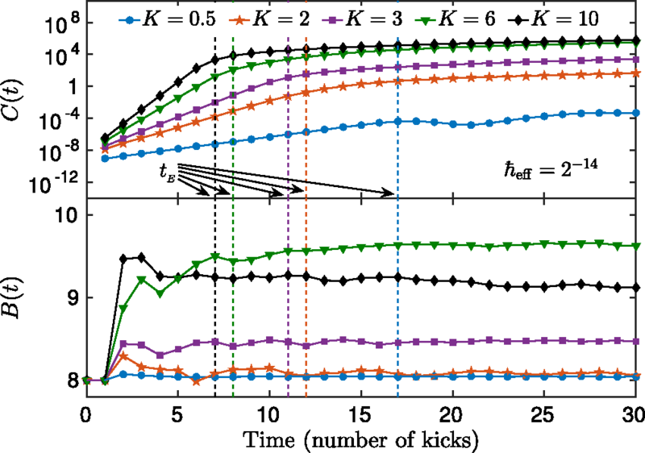

**FIG. 1.** The upper panel shows the OTOC $C(t)$ vs $t$ in the semilog scale for various values of the kicking strength ($K=0.5$, $2$, $3$, $6$, $10$) and $\hbar_\mathrm{eff}=2^{-14}$. The lower panel is a plot of the two-point function $B(t)$ vs $t$ at the corresponding parameters (in the linear scale). Averaging is performed over the Gaussian wave packet defined in Eq. (4) with $p_0=0$ and $\sigma=4$.

# Figure

```julia
using Plots
using FFTW
using LaTeXStrings
```

## Fig. 1

```julia
hbar_eff=2^(-5)
N=Int64(2^5/hbar_eff/2)
p0=0
n0=p0/hbar_eff
sigma=4
n=Vector(-N:N-1)
x=(n.+N)./(2*N).*(2*pi)
psi0=exp.(-(n.-n0).^2*hbar_eff^2/(2*sigma^2));
psi_p=psi0
psi_x=ifftshift(ifft(psi_p));
```

```julia
plot_p=plot(n,(abs.(psi_p)).^2,title=L"\mathrm{Initial\ State\ }\Psi(0)\mathrm{\ in\ Momentum\ Space}",xlabel=L"n",legend=false)
plot_x=plot(x,(abs.(psi_x)).^2,title=L"\mathrm{Initial\ State\ }\Psi(0)\mathrm{\ in\ Position\ Space}",xlabel=L"x",legend=false)
plot(plot_p,plot_x,layout=(2,1))
```

[figure not shown]

```julia
function forward_kick(state_p,kick_strength,kick_times)
    for t in 1:kick_times
        state_x=ifft(state_p)
        state_x=exp.(-1im*kick_strength/hbar_eff.*cos.(x)).*state_x
        state_p=exp.(-1im*hbar_eff/2*(n.^2)).*fft(state_x)
    end
    return state_p
end
function backward_kick(state_p,kick_strength,kick_times)
    for t in 1:kick_times
        state_p=exp.(1im*hbar_eff/2*(n.^2)).*state_p
        state_x=ifft(state_p)
        state_x=exp.(1im*kick_strength/hbar_eff*cos.(x)).*state_x
        state_p=fft(state_x)
    end
    return state_p
end
function correlators(state_p,kick_strength,kick_times)
    state_p_1=hbar_eff*n.*state_p
    state_p_1=forward_kick(state_p_1,kick_strength,kick_times)
    state_p_1=hbar_eff*n.*state_p_1
    state_p_1=backward_kick(state_p_1,kick_strength,kick_times)

    state_p_2=forward_kick(state_p,kick_strength,kick_times)
    state_p_2=hbar_eff*n.*state_p_2
    state_p_2=backward_kick(state_p_2,kick_strength,kick_times)
    state_p_2=hbar_eff*n.*state_p_2

    b=real(sum(conj(state_p).*state_p_1))/rho_0
    c=log(sum(abs.(state_p_1-state_p_2).^2)/rho_0)
    return b,c
end
```

```
correlators (generic function with 1 method)
```

```julia
phi=fft(psi_x);
plot_original=plot(n,abs.(phi).^2,legend=false,title=L"\mathrm{Original}",xlabel=L"n")
phi_10=forward_kick(phi,0.5,10)
plot_forward=plot(n,abs.(phi_10).^2,legend=false,title=L"\mathrm{Forward}",xlabel=L"n")
phi_0=backward_kick(phi_10,0.5,10)
plot_backward=plot(n,abs.(phi_0).^2,legend=false,title=L"\mathrm{Backward}",xlabel=L"n")
plot(plot_original,plot_forward,plot_backward,layout=(3,1),lengend=false)
```

[figure not shown]

```julia
rho_0=sum(abs.(phi).^2)
kick_length=10
K_value=[0.5,2,3,6,10]
b_t=zeros(Float64,kick_length,length(K_value))
c_t=zeros(Float64,kick_length,length(K_value))

for ii in 1:length(K_value)
    K=K_value[ii]
for t in 1:kick_length
    b_t[t,ii],c_t[t,ii]=correlators(psi0,K,t)
end

end
plot_c=plot(1:kick_length,c_t,ylabel=L"C(t)")
plot_b=plot(1:kick_length,b_t,ylabel=L"B(t)",xlabel=L"\mathrm{Time\ (number\ of\ kicks)}")
plot(plot_c,plot_b,layout=(2,1),legend=false)
```

[figure not shown]